# Advanced Data Analytics – D213 Task 1: Time Series Modeling

##### Part III: Data Preparation

###### Section C. Review data cleaning process

The first step in the analytic pre-process is to load required libraries and dependencies for the specific operation.

```python
import pandas as pd
import scipy.stats as scs
from datetime import datetime
import matplotlib as mpl
import matplotlib.pyplot as plt
%matplotlib inline
%config InlineBackend.figure_format = 'retina'
import seaborn as sns
sns.set_context("poster")
sns.set(rc={'figure.figsize': (16, 9.)})
sns.set_style("whitegrid")

from sklearn.metrics import mean_squared_error
from sklearn.model_selection import train_test_split
from sklearn import preprocessing

import pmdarima as pm
from pmdarima.model_selection import train_test_split
from pmdarima import auto_arima

import statsmodels.api as sm
from statsmodels.tsa.stattools import adfuller
from statsmodels.tsa.arima_model import ARIMA
from statsmodels.tsa.seasonal import seasonal_decompose
from statsmodels.graphics.tsaplots import plot_acf
from statsmodels.tsa.ar_model import AR
from statsmodels.tools.eval_measures import rmse
```

The second step in the analytic pre-process is to apply formatting to enhance practical & visual functionality of notebook.

```python
from IPython.core.display import display, HTML
display(HTML("<style>.container { width:80% !important; }</style>"))

plt.style.use('ggplot')
import warnings
warnings.filterwarnings('ignore')
```

Next read in the dataset

```python
dataset = pd.read_csv(r"C:/Users/Admin/Desktop/teleco_time_series.csv")
```

Next, EDA (Exploratory Data Analysis)

```python
dataset.head()
```

|  | Day | Revenue |
| --- | --- | --- |
| 0 | 1 | 0.000000 |
| 1 | 2 | 0.000793 |
| 2 | 3 | 0.825542 |
| 3 | 4 | 0.320332 |
| 4 | 5 | 1.082554 |

Examine attributes data-types

```python
dataset.dtypes
```

```
Day          int64
Revenue    float64
dtype: object
```

Check for missing values and NAs

```python
print(dataset.isnull().values.any())
print(dataset.isna().values.any())
```

```
False
False
```

Check dataset for duplicates

```python
print(dataset.Revenue.duplicated().sum())
```

```
0
```

Examine basic data statistics

```python
print(dataset.describe())
```

```
              Day     Revenue
count  731.000000  731.000000
mean   366.000000    9.822901
std    211.165812    3.852645
min      1.000000    0.000000
25%    183.500000    6.872836
50%    366.000000   10.785571
75%    548.500000   12.566911
max    731.000000   18.154769
```

Check basic information

```python
dataset.info
```

```
<bound method DataFrame.info of      Day    Revenue
0      1   0.000000
1      2   0.000793
2      3   0.825542
3      4   0.320332
4      5   1.082554
..   ...        ...
726  727  16.931559
727  728  17.490666
728  729  16.803638
729  730  16.194814
730  731  16.620798

[731 rows x 2 columns]>
```

###### C.2. Conclusions

The two attributes data types are 'Day' which is a datatype int64 and 'Revenue' which is a datatype float64. There appears to be no nulls, NA's, or dupliocates in dataset. The 'Day' attribute is a sequence running from 1 to 731, which could easily be used as an index for the dataset. The 'Revenue' attribute is shown in millions, with a minimum of 0 and a maximum of 18.15. There appears to be no gaps in measurement and the length of the sequence.

###### C.3. Appraisal of stationarity

Visual examination

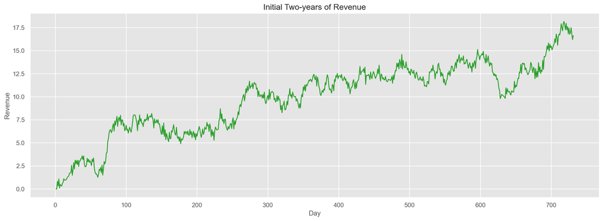

```python
def plot_df(dataset, x, y, title='', xlabel='Day', ylabel='Revenue', dpi=100):
    plt.figure(figsize=(18, 6), dpi=dpi)
    plt.plot(x, y, color='tab:green')
    plt.gca().set(title=title, xlabel=xlabel, ylabel=ylabel)
    plt.show()

plot_df(dataset, x=dataset['Day'], y=dataset["Revenue"],title= 'Initial Two-years of Revenue')
```

Engage the Augmented Dickey Fuller test (ADF Test) which is a common statistical test used to test whether a given time series is stationary or not. It is one of the most commonly used statistical test when it comes to analyzing the stationarity of a time series.

```python
x = dataset['Revenue']
adft = adfuller(x,autolag="AIC")
```

```python
output_df = pd.DataFrame({"Values":[adft[0],adft[1],adft[2],adft[3], adft[4]['1%'], adft[4]['5%'], adft[4]['10%']]  , "Metric":["Test Statistics","p-value","No. of lags used","Number of observations used",
                                                        "critical value (1%)", "critical value (5%)", "critical value (10%)"]})
print(output_df)
```

```
       Values                       Metric
0   -1.924612              Test Statistics
1    0.320573                      p-value
2    1.000000             No. of lags used
3  729.000000  Number of observations used
4   -3.439352          critical value (1%)
5   -2.865513          critical value (5%)
6   -2.568886         critical value (10%)
```

#### Analyze the rolling mean.

```python
rolling_mean = dataset.rolling(50).mean()
```

Visualizing mean and rolling mean

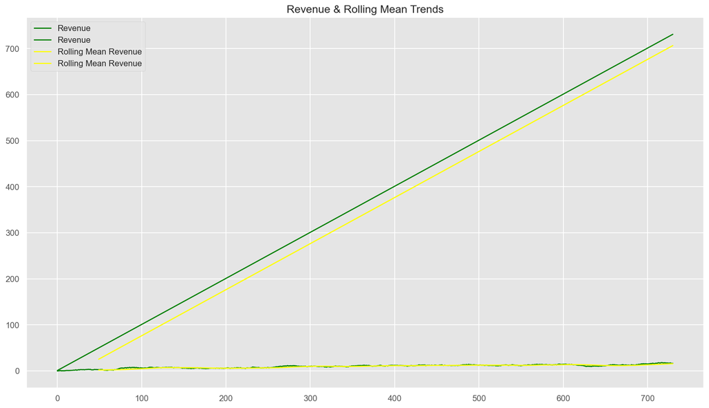

```python
plt.plot(dataset, color="green",label="Revenue")
plt.plot(rolling_mean, color="yellow", label="Rolling Mean Revenue")
plt.title("Revenue & Rolling Mean Trends")
plt.legend(loc="best")
```

###### C.3. Conclusion, Results of stationarity test:

We can see that our data is not stationary from the evidence that our p-value is greater than 5 percent. The test statistic is greater than the critical value. We can also draw these conclusions from inspecting the visuals, as we see a clear, increasing trends. All of which indicates that the mean and varaition is not 0. Therefore we cannot reject the null hypothesis and the time series is not stationary.

###### C.4. Preparing the data for analysis, including the training and test set split.

```python
#Train set of 400 tuples
dataset['Day'] = dataset.index
data_train = dataset.iloc[:len(dataset) - 331]
data_train['data_train'] = data_train['Revenue']
del data_train['Day']
del data_train['Revenue']
```

```python
# Test set of 331 tuples
data_test = dataset.iloc[len(dataset) - 331:]
data_test['data_test'] = data_test['Revenue']
del data_test['Day']
del data_test['Revenue']
```

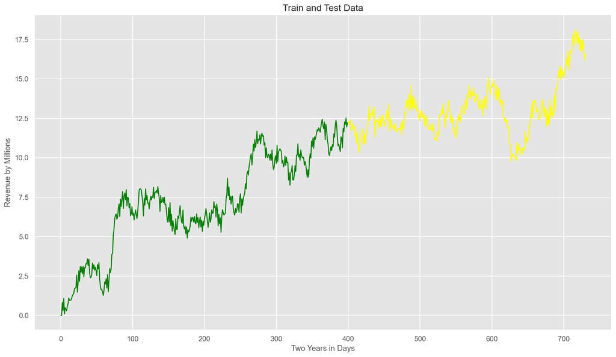

```python
# Visualize training and test sets side-by-side
plt.plot(data_train, color='green')
plt.plot(data_test, color='yellow')
plt.title('Train and Test Data')
plt.xlabel('Two Years in Days')
plt.ylabel('Revenue by Millions')
sns.set()
plt.show()
```

###### C.4. Conclusion, steps utilized to prepare the data for aalysis

Step 1, Read in dataset Step 2, Visualize dataset Step 3, View first few rows of data Step 4, Examine data-types Step 5, Check for missing values and NAs Step 6, Check dataset for duplicates Step 7, Examined basic data statistics Step 8, Check basic information Step 9, Split data into a train set of 400 tuples and a test set of 331 Tuples with visualization

###### C.5. Clean dataset exported for submission

```python
dataset.to_csv(r"C:/Users/Admin/Desktop/cleaned.csv")
```

##### Part IV: Model Identification and Analysis

###### D.1. Analyze the time series dataset by doing the following:

###### D.1.a. Seasonal Component Analysis

Source code from research Portilla (2020)

Decompose data_train set

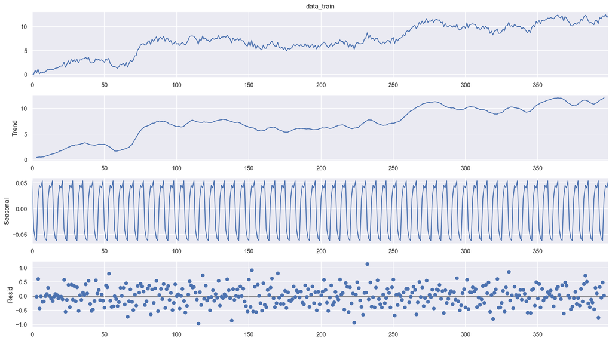

```python
from statsmodels.tsa.seasonal import seasonal_decompose
decompose = seasonal_decompose(data_train['data_train'], model='additive', period=7)
decompose.plot()
plt.show()
```

###### D.1.b. Visualize trend component

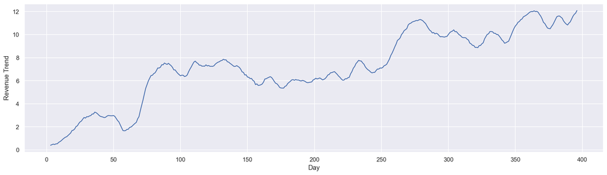

```python
decompose_trend = decompose.trend
ax = decompose_trend.plot(figsize=(19,5))
ax.set_xlabel('Day')
ax.set_ylabel('Revenue Trend')
```

###### D.1.c. Autocorrelation Analysis

Source code from research Portilla (2020)

Autocorrelation Plot with lag = 90

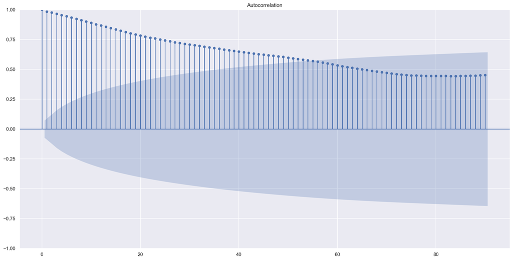

```python
plt.rc("figure", figsize=(20,10))
plt.figure(figsize=(20,10))
plot_acf(x, lags=90)
plt.show()
```

Autocorrelation Plot with lag = 50

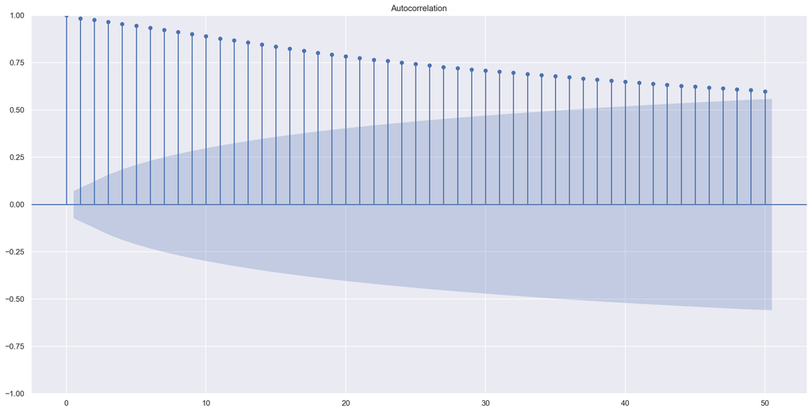

```python
plt.rc("figure", figsize=(20,10))
plt.figure(figsize=(20,10))
plot_acf(x, lags=50)
plt.show()
```

###### D.1.d. Perform spectral density function

In research from Wikipedia contributors (2021,) the power spectrum Sₓₓ(f) of a time series x(t) describes the distribution of power into frequency components composing that signal. According to Fourier analysis, any physical signal can be decomposed into a number of discrete frequencies, or a spectrum of frequencies over a continuous range. The statistical average of a certain signal or sort of signal (including noise) as analyzed in terms of its frequency content, is called its spectrum.

[output not shown]

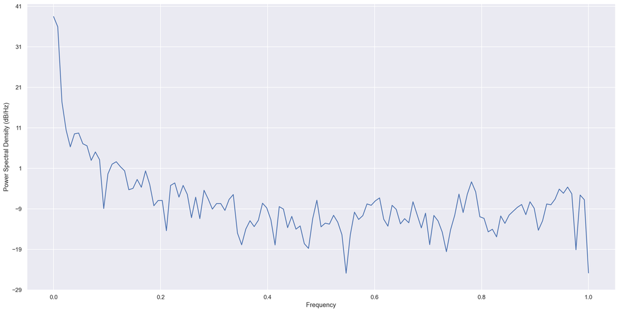

```python
plt.psd(dataset['Revenue'])
```

###### D.1.e. the decomposed time series

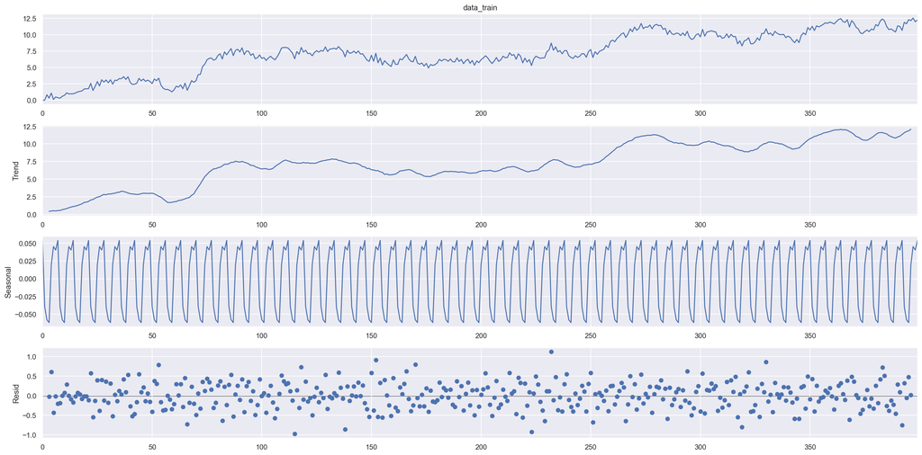

```python
decompose = seasonal_decompose(data_train['data_train'], model='additive', period=7)
decompose.plot()
plt.show()
```

Differencing the data

```python
initial_diff = dataset.diff().dropna()
```

Perform Augmented Dickey Fuller test (ADF Test) on the differenced DataFrame

```python
result = adfuller(initial_diff['Revenue'])
```

Produce ADF-test statistic and p-value of differenced dataset

```python
print('ADF statistic:', result[0])
print('p-value:', result[1])
```

```
ADF statistic: -44.874527193875984
p-value: 0.0
```

Visualize the result

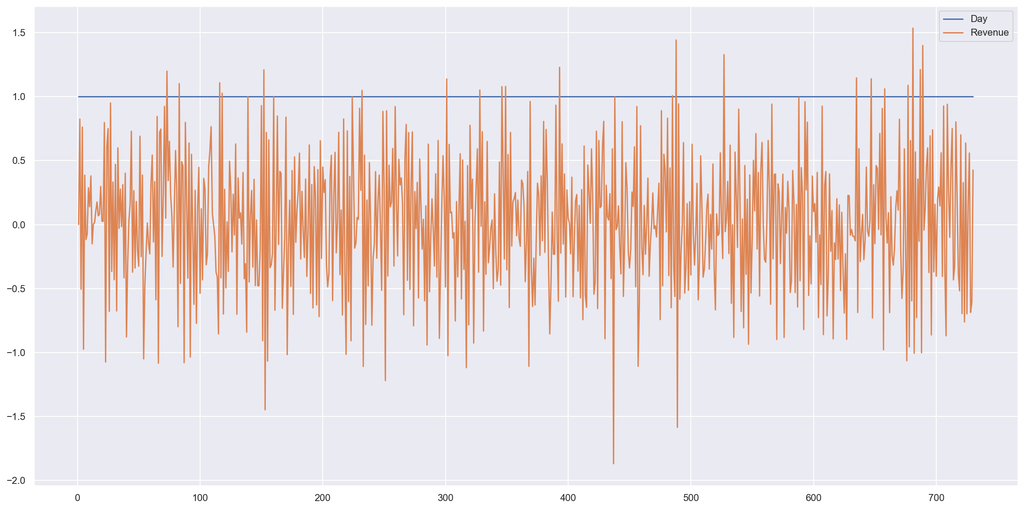

```python
fig, ax = plt.subplots()
initial_diff.plot(ax=ax)
plt.show()
```

###### D.2. Identifying an ARIMA model offsetting the observed trend and seasonality

The data is not stationary as we can clearly observe from the evidence that the p-value is greater than 5 percent and the test statistic is greater than the critical value. In addition, the conclusions can be drawn from visual inspection, we clearly see an increasing trend. All of which indicates that the mean and variation are not 0. Therefore, we cannot reject the null hypothesis as this time series is non-stationary.

According to new research (Chedalavada, 2021), non-stationary data is unpredictable in nature, by definition, and cannot be predicted or modelled. If we employ this non-stationary time series, the results may be inauthentic, and may parody a relationship between variables that does not exist.

In research from Swanson (2016) there are four highly cited time series models used for forecasting that might provide a solution to our non-stationarity hindrance. They are.

• ARIMA model • Holt Winter’s Exponential Smoothing • TBATS models • SPLINE models

The ARIMA model produces the most consistent results across a range of applications. In conjunction with smaller prediction errors and a tighter prediction range, compared to the alternative models.

ARMA model According to new research from (Mohr, 2020), ARMA (Autoregressive Moving Average) model forecasts apply advanced econometric modeling techniques to forecast time-series data by first backfitting to historical data and then forecasting the future.

ARIMA model Auto-regressive-integrated-moving-average (ARIMA) models rank as the fundamental pillar for time-series modeling.

SARIMA model The SARIMA model, (Seasonal Autoregressive Integrated Moving Average), which is used for time series in conjunction with seasonal components and the model we will utilize for this project. This model is an extension of ARIMA that adds seasonal terms. The parameters of sets not only encompass the ARIMA p,d,q, but also P,D,Q for seasonal concerns.

###### D.2.a. Differencing out the trend

The above differencing has produced a p-value to 0 and an average mean of 0, consequently removing trend from our analysis.

The results have provided an acceptable p-value (0.0) that can fit the ARIMA model. The auto_arima model will be fitted to the data to produce the optimum ARIMA paradigm.

Source code from research Brownlee (2020)

Stepwise search to minimize aic, iterating to find optimum p,d,q

```python
auto_arima_fit = auto_arima(dataset['Revenue'], start_P=1, start_q=1, max_p=3, max_q=3, m=12, seasonal=True, d=None, D=1,
                            trace=True, error_action='ignore', suppress_warnings=True, stepwise=True)
```

```
Performing stepwise search to minimize aic
 ARIMA(2,0,1)(1,1,1)[12] intercept   : AIC=inf, Time=5.48 sec
 ARIMA(0,0,0)(0,1,0)[12] intercept   : AIC=2367.159, Time=0.04 sec
 ARIMA(1,0,0)(1,1,0)[12] intercept   : AIC=1419.537, Time=1.00 sec
 ARIMA(0,0,1)(0,1,1)[12] intercept   : AIC=1969.738, Time=0.70 sec
 ARIMA(0,0,0)(0,1,0)[12]             : AIC=2399.547, Time=0.03 sec
 ARIMA(1,0,0)(0,1,0)[12] intercept   : AIC=1568.311, Time=0.18 sec
 ARIMA(1,0,0)(2,1,0)[12] intercept   : AIC=1320.755, Time=2.02 sec
 ARIMA(1,0,0)(2,1,1)[12] intercept   : AIC=inf, Time=6.97 sec
 ARIMA(1,0,0)(1,1,1)[12] intercept   : AIC=inf, Time=4.66 sec
 ARIMA(0,0,0)(2,1,0)[12] intercept   : AIC=2339.965, Time=0.81 sec
 ARIMA(2,0,0)(2,1,0)[12] intercept   : AIC=1147.041, Time=3.67 sec
 ARIMA(2,0,0)(1,1,0)[12] intercept   : AIC=1256.245, Time=1.66 sec
 ARIMA(2,0,0)(2,1,1)[12] intercept   : AIC=inf, Time=6.84 sec
 ARIMA(2,0,0)(1,1,1)[12] intercept   : AIC=inf, Time=4.88 sec
 ARIMA(3,0,0)(2,1,0)[12] intercept   : AIC=1148.348, Time=4.61 sec
 ARIMA(2,0,1)(2,1,0)[12] intercept   : AIC=1148.544, Time=4.37 sec
 ARIMA(1,0,1)(2,1,0)[12] intercept   : AIC=1195.703, Time=3.85 sec
 ARIMA(3,0,1)(2,1,0)[12] intercept   : AIC=1133.013, Time=11.48 sec
 ARIMA(3,0,1)(1,1,0)[12] intercept   : AIC=1235.930, Time=5.84 sec
 ARIMA(3,0,1)(2,1,1)[12] intercept   : AIC=inf, Time=13.13 sec
 ARIMA(3,0,1)(1,1,1)[12] intercept   : AIC=inf, Time=6.85 sec
 ARIMA(3,0,2)(2,1,0)[12] intercept   : AIC=1132.707, Time=12.57 sec
 ARIMA(3,0,2)(1,1,0)[12] intercept   : AIC=1236.060, Time=6.84 sec
 ARIMA(3,0,2)(2,1,1)[12] intercept   : AIC=inf, Time=12.57 sec
 ARIMA(3,0,2)(1,1,1)[12] intercept   : AIC=inf, Time=7.01 sec
 ARIMA(2,0,2)(2,1,0)[12] intercept   : AIC=1142.858, Time=5.22 sec
 ARIMA(3,0,3)(2,1,0)[12] intercept   : AIC=1135.885, Time=14.66 sec
 ARIMA(2,0,3)(2,1,0)[12] intercept   : AIC=1139.693, Time=10.51 sec
 ARIMA(3,0,2)(2,1,0)[12]             : AIC=1135.369, Time=2.29 sec

Best model:  ARIMA(3,0,2)(2,1,0)[12] intercept
Total fit time: 160.831 seconds
```

In research from Prabhakaran (2021b) third party source code

Summarization of auto_arima

```python
auto_arima_fit.summary()
```

SARIMAX Results

| Dep. Variable: | y | No. Observations: | 731 |
| --- | --- | --- | --- |
| Model: | SARIMAX(3, 0, 2)x(2, 1, [], 12) | Log Likelihood | -557.353 |
| Date: | Sat, 18 Dec 2021 | AIC | 1132.707 |
| Time: | 12:02:43 | BIC | 1173.907 |
| Sample: | 0 | HQIC | 1148.613 |
|  | - 731 |  |  |
| Covariance Type: | opg |  |  |

|  | coef | std err | z | P>\|z\| | [0.025 | 0.975] |
| --- | --- | --- | --- | --- | --- | --- |
| intercept | 0.0062 | 0.003 | 1.823 | 0.068 | -0.000 | 0.013 |
| ar.L1 | 1.4373 | 0.073 | 19.600 | 0.000 | 1.294 | 1.581 |
| ar.L2 | -0.0305 | 0.126 | -0.243 | 0.808 | -0.277 | 0.216 |
| ar.L3 | -0.4183 | 0.070 | -5.984 | 0.000 | -0.555 | -0.281 |
| ma.L1 | -0.9710 | 0.082 | -11.868 | 0.000 | -1.131 | -0.811 |
| ma.L2 | 0.1062 | 0.077 | 1.371 | 0.171 | -0.046 | 0.258 |
| ar.S.L12 | -0.7119 | 0.038 | -18.636 | 0.000 | -0.787 | -0.637 |
| ar.S.L24 | -0.3840 | 0.039 | -9.805 | 0.000 | -0.461 | -0.307 |
| sigma2 | 0.2713 | 0.015 | 17.704 | 0.000 | 0.241 | 0.301 |

| Ljung-Box (L1) (Q): | 0.00 | Jarque-Bera (JB): | 1.88 |
| --- | --- | --- | --- |
| Prob(Q): | 0.97 | Prob(JB): | 0.39 |
| Heteroskedasticity (H): | 1.06 | Skew: | 0.01 |
| Prob(H) (two-sided): | 0.63 | Kurtosis: | 2.75 |

Warnings:  
[1] Covariance matrix calculated using the outer product of gradients (complex-step).

The findings of the auto-arima according to new research from (Prabhakaran, 2021), encouragement the assumption that the preeminent model is (p=3, d=0, q=2) and seasonality (P=2, D=1, Q=0) [12] Where: (p) being the order of the autoregressive (AR) term equals the number of lags to be used as predictors (d) being the integrated (I) term equals the minimum number of differencing used to make the data stationary (q) being the order of the moving average (MA) term equals the number of lagged pre-forecast errors to be used

The findings of the auto-arima encouragement the assumption that the preeminent model is (p=3, d=0, q=2) and for seasonality (P=2, D=1, Q=0) [12] (p) being the order of the autoregressive (AR) term equals the number of lags to be used as predictors (d) being the integrated (I) term equals the minimum number of differencing used to make the data stationary (q) being the order of the moving average (MA) term equals the number of lagged pre-forecast errors to be used

These mixed models are called SARIMA(p,d,q)x(P,D, Q)_S, the lower case letters denote the orders of the nonseasonal components and the capital letters refer to the seasonal components.

From here we will reiterate our modeling with the auto-arima provided p,d,q assumptions.

Train set of 400 tuples

```python
dataset['Day'] = dataset.index
data_train = dataset.iloc[:len(dataset) - 331]
data_train['data_train'] = data_train['Revenue']
del data_train['Day']
del data_train['Revenue']
```

Test set of 331 tuples

```python
data_test = dataset.iloc[len(dataset) - 331:]
data_test['data_test'] = data_test['Revenue']
del data_test['Day']
del data_test['Revenue']
```

Visualize training and testing datasets and their transition point

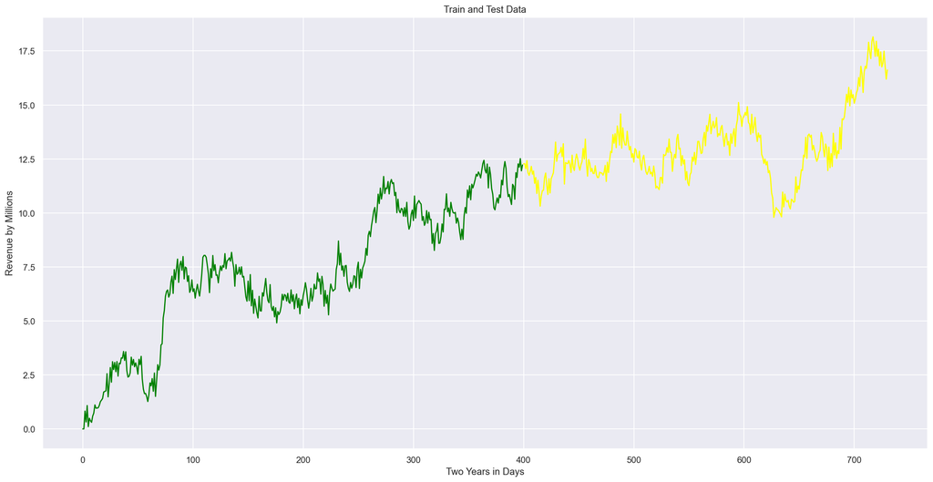

```python
plt.plot(data_train, color='green')
plt.plot(data_test, color='yellow')
plt.title('Train and Test Data')
plt.xlabel('Two Years in Days')
plt.ylabel('Revenue by Millions')
sns.set()
plt.show()
```

Identified autoregressive integrated moving average (ARIMA) model, which counterbalances for observed trends and seasonality.

```python
model = sm.tsa.SARIMAX(data_train,
                       order=(3, 0, 2),
                       seasonal_order=(2, 1, 0, 12),
                       enforce_stationarity=False,
                       enforce_invertibility=False)

SARIMAX_results = model.fit()

print(SARIMAX_results.summary())
```

```
                                      SARIMAX Results
===========================================================================================
Dep. Variable:                          data_train   No. Observations:                  400
Model:             SARIMAX(3, 0, 2)x(2, 1, [], 12)   Log Likelihood                -278.390
Date:                             Sat, 18 Dec 2021   AIC                            572.781
Time:                                     12:02:45   BIC                            603.892
Sample:                                          0   HQIC                           585.150
                                             - 400
Covariance Type:                               opg
==============================================================================
                 coef    std err          z      P>|z|      [0.025      0.975]
------------------------------------------------------------------------------
ar.L1          1.2218      0.176      6.959      0.000       0.878       1.566
ar.L2          0.0917      0.166      0.552      0.581      -0.234       0.417
ar.L3         -0.3353      0.138     -2.433      0.015      -0.606      -0.065
ma.L1         -0.6878      0.179     -3.849      0.000      -1.038      -0.338
ma.L2          0.0992      0.120      0.826      0.409      -0.136       0.334
ar.S.L12      -0.8011      0.055    -14.453      0.000      -0.910      -0.692
ar.S.L24      -0.4103      0.056     -7.342      0.000      -0.520      -0.301
sigma2         0.2735      0.023     11.914      0.000       0.229       0.319
===================================================================================
Ljung-Box (L1) (Q):                   0.01   Jarque-Bera (JB):                 2.09
Prob(Q):                              0.91   Prob(JB):                         0.35
Heteroskedasticity (H):               0.95   Skew:                            -0.00
Prob(H) (two-sided):                  0.78   Kurtosis:                         2.63
===================================================================================

Warnings:
[1] Covariance matrix calculated using the outer product of gradients (complex-step).
```

Forecast results

```python
result = SARIMAX_results.get_forecast()
# Summarize forecast and confidence intervals
test_1 = data_test['data_test'].values.astype('float32')
forecast = result.predicted_mean
print('Expected: %.2f' % forecast)
print('Forecast: %.2f' % test_1[0])
print('Standard Error: %.2f' % result.se_mean)
```

```
Expected: 12.36
Forecast: 12.27
Standard Error: 0.52
```

Examine Confidence Intervals

```python
intervals = [0.2, 0.1, 0.05, 0.01]
for a in intervals:
    ci = result.conf_int(alpha=a)
    print('%.1f%% Confidence Interval: %.2f between %.2f and %.2f' % ((1 - a) * 100, forecast, ci['lower data_train'], ci['upper data_train']))

ci
```

```
80.0% Confidence Interval: 12.36 between 11.69 and 13.03
90.0% Confidence Interval: 12.36 between 11.50 and 13.22
95.0% Confidence Interval: 12.36 between 11.33 and 13.38
99.0% Confidence Interval: 12.36 between 11.01 and 13.70
```

|  | lower data_train | upper data_train |
| --- | --- | --- |
| 400 | 11.010371 | 13.704615 |

###### D. 3. Forecasting using the derived ARIMA model.

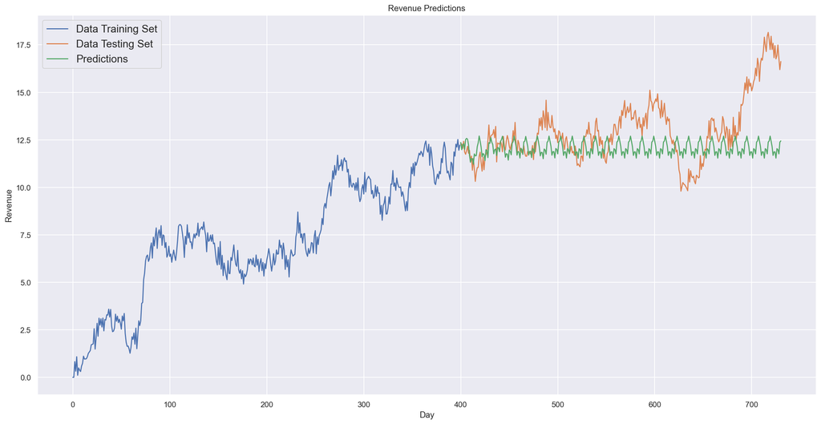

```python
start = len(data_train)
end = len(data_train) + len(data_test) - 1
# Predict with respect to test set
predictions = SARIMAX_results.predict(start, end, typ = 'levels').rename('Predictions')
plt.plot(data_train, label = 'Data Training Set')
plt.plot(data_test, label = 'Data Testing Set')
plt.plot(predictions, label = 'Predictions')
plt.title('Revenue Predictions')
plt.xlabel('Day')
plt.ylabel('Revenue')
plt.legend(loc='upper left', fontsize = 15)
plt.show()
```

Source code from research Maklin (2021)

Train model

```python
model = sm.tsa.statespace.SARIMAX(dataset['Revenue'],
                                  order=(3, 0, 2),
                                  seasonal_order=(2, 1, 0, 12),
                                  enforce_stationarity=False,
                                  enforce_invertibility=False)
results = model.fit()
```

Forecasting / Predicting

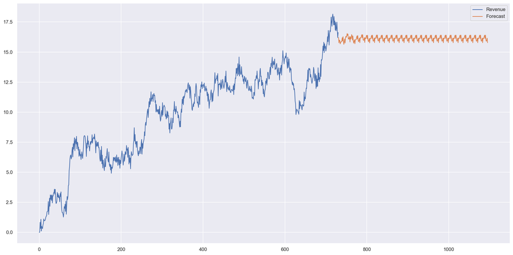

```python
forecast = results.predict(start=len(dataset['Revenue']),
                           end=(len(dataset['Revenue']) - 1) + 365,
                           typ='level').rename('Forecast')
# Visualize predicted values
dataset['Revenue'].plot(figsize=(20, 10), legend=True)
forecast.plot(legend=True)
```

Produce Mean Squared Error (MSE)

```python
MSE = mean_squared_error(data_test['data_test'], predictions)
print('MSE: ', round(MSE, 4))
```

```
MSE:  3.7405
```

```python
# Run Root Mean Squared Error
RMSE = rmse(data_test['data_test'], predictions)
print('RMSE: ', round(RMSE, 4))
```

```
RMSE:  1.934
```

##### Part V Summation and Inferences

###### E.1.a. ARIMA model selection

The selection of the Autoregressive Integrated Moving Average (ARIMA) model was fitted using the Auto-Arima function producing the autoregressive (AR) number of optimal lags (3), the ideal integrated (I) to compensate for the differencing (0), and the most appropriate order of the moving average (MA)(2) terms to be used. In both the seasonal and non-seasonal components. Seasonal concsisted of (P=2, D=1, Q =0), with seasons of 12.

###### E.1.b. Prediction interval of the forecast

The four intervals of confidence levels were tested at 80, 90, 95, and 99% of accuracy. Using the 95% statistical benchmark of the risk that the daily revenue will not be within the range of 11.33 million and 13.38 million is less than 5% for not meeting this forecast.

80.0% Confidence Interval: 12.36 between 11.69 and 13.03 90.0% Confidence Interval: 12.36 between 11.50 and 13.22 95.0% Confidence Interval: 12.36 between 11.33 and 13.38 99.0% Confidence Interval: 12.36 between 11.01 and 13.70

###### E.1.d. Model evaluation procedure and error metric

The Mean Square Error is the average of square of difference between the predicted values and true values. Sklearn provides it as a function. It has the same units as the true and predicted values squared and is always positive. The closer to 0 the more accurate.

Root Mean Square Error is the square root of the mean square error. It is also always positive and is in the range of the data. Also assessed as the nearer to 0 the more accurate.

###### E.2. Visualization of the Forecast

Annotated visualization of the forecast of the final model compared with test set.

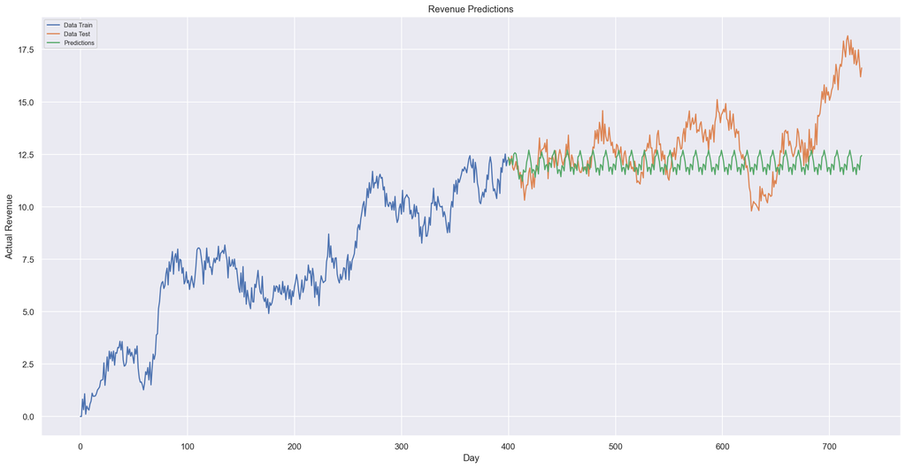

```python
start = len(data_train)
end = len(data_train) + len(data_test) - 1
# Predict with respect to test set
predictions = SARIMAX_results.predict(start, end, typ = 'levels').rename('Predictions')
plt.plot(data_train, label = 'Data Train')
plt.plot(data_test, label = 'Data Test')
plt.plot(predictions, label = 'Predictions')
plt.title('Revenue Predictions')
plt.xlabel('Day')
plt.ylabel('Actual Revenue')
plt.legend(loc='upper left', fontsize = 8)
plt.show()
```

###### E.3. Recommend a course of action

The specific action recommended is to be courageous, take considered risks, and dominate the telecommunications industry, trusting in sound data analysis and insightful business intelligence.

##### Part VI: Reporting

###### F. Industry-relevant interactive development environment

This report was produced utilizing the leading industry-relevant interactive development environment Jupyter Notebooks, and delivered as an HTML document.

###### G. & H. References & Third-party code resources

###### References and Code Resources

Brownlee, J. (2020, December 10). How to Create an ARIMA Model for Time Series Forecasting in Python. Machine Learning Mastery. Retrieved December 14, 2021, from https://machinelearningmastery.com/arima-for-time-series-forecasting-with-python/

Chedalavada, V. (2021, July 20). Analysis of Time Series Data - Analytics Vidhya. Medium. Retrieved December 18, 2021, from https://medium.com/analytics-vidhya/analysis-of-time-series-data-dad4afa56358

Hamilton, J. D. (1994). Time Series Analysis (1st ed.). Princeton University Press.

Maklin, C. (2021, December 10). ARIMA Model Python Example — Time Series Forecasting. Medium. Retrieved December 14, 2021, from https://towardsdatascience.com/machine-learning-part-19-time-series-and-autoregressive-integrated-moving-average-model-arima-c1005347b0d7

Mohr, F. X. (2020, August 9). An Introduction to Stationarity and Unit Roots in Time Series Analysis · r-econometrics. R-Econometrics. Retrieved December 7, 2021, from https://www.r-econometrics.com/timeseries/stationarity/

Portilla, J. M. (2016, September 16). Build software better, together. GitHub. Retrieved December 1, 2021, from https://github.com/topics/jose-portilla

Portilla, J. M. (2020, June 29). Using Python and Auto ARIMA to Forecast Seasonal Time Series. Medium. Retrieved December 12, 2021, from https://medium.com/@josemarcialportilla/using-python-and-auto-arima-to-forecast-seasonal-time-series-90877adff03c

Prabhakaran, S. (2021, November 22). ARIMA Model - Complete Guide to Time Series Forecasting in Python | ML+. Machine Learning Plus. Retrieved December 14, 2021, from https://www.machinelearningplus.com/time-series/arima-model-time-series-forecasting-python/

Prabhakaran, S. (2021b, November 22). Augmented Dickey-Fuller (ADF) Test - Must Read Guide - ML+. Machine Learning Plus. Retrieved December 12, 2021, from https://www.machinelearningplus.com/time-series/augmented-dickey-fuller-test/

Swanson, T. S. (2016, November 31). Time-Series Methods in Experimental Research. Psychologicalscience.Org. Retrieved December 12, 2021, from https://www.psychologicalscience.org/observer/time-series-methods-in-experimental-research

Wikipedia contributors. (2021, October 20). Spectral density. Wikipedia. Retrieved December 1, 2021, from https://en.wikipedia.org/wiki/Spectral_density

Any question or comments regarding this report may be directed the analyst at jboni27@wgu.edu Thank you for your interest.